# Submission- NLP_Project

## **Problem Statement**

### Business Context

The prices of the stocks of companies listed under a global exchange are influenced by a variety of factors, with the company's financial performance, innovations and collaborations, and market sentiment being factors that play a significant role. News and media reports can rapidly affect investor perceptions and, consequently, stock prices in the highly competitive financial industry. With the sheer volume of news and opinions from a wide variety of sources, investors and financial analysts often struggle to stay updated and accurately interpret its impact on the market. As a result, investment firms need sophisticated tools to analyze market sentiment and integrate this information into their investment strategies.

### Problem Definition

With an ever-rising number of news articles and opinions, an investment startup aims to leverage artificial intelligence to address the challenge of interpreting stock-related news and its impact on stock prices. They have collected historical daily news for a specific company listed under NASDAQ, along with data on its daily stock price and trade volumes.

As a member of the Data Science and AI team in the startup, you have been tasked with analyzing the data, developing an AI-driven sentiment analysis system that will automatically process and analyze news articles to gauge market sentiment, and summarizing the news at a weekly level to enhance the accuracy of their stock price predictions and optimize investment strategies. This will empower their financial analysts with actionable insights, leading to more informed investment decisions and improved client outcomes.

### Data Dictionary

- `Date` : The date the news was released
- `News` : The content of news articles that could potentially affect the company's stock price
- `Open` : The stock price (in \$) at the beginning of the day
- `High` : The highest stock price (in \$) reached during the day
- `Low` : The lowest stock price (in \$) reached during the day
- `Close` : The adjusted stock price (in \$) at the end of the day
- `Volume` : The number of shares traded during the day
- `Label` : The sentiment polarity of the news content
  - 1: positive
  - 0: neutral
  - -1: negative

## **Installing and Importing Necessary Libraries**

```python
# installing the sentence-transformers and gensim libraries for word embeddings
!pip install -U sentence-transformers gensim transformers contractions tqdm -q
```

[output not shown]

```python
# to read and manipulate the data
import pandas as pd
import numpy as np
pd.set_option('max_colwidth', None)    # setting column to the maximum column width as per the data

# to visualise data
import matplotlib.pyplot as plt
import seaborn as sns

# to use regular expressions for manipulating text data
import re

# to manipulate string data
import string

# to load the natural language toolkit
import nltk
nltk.download('stopwords')    # loading the stopwords
nltk.download('wordnet')    # loading the wordnet module that is used in stemming
# To encode the target variable
from sklearn.preprocessing import LabelEncoder

# To import Word2Vec
from gensim.models import Word2Vec

# Converting the Stanford GloVe model vector format to word2vec
from gensim.scripts.glove2word2vec import glove2word2vec
from gensim.models import KeyedVectors

# to remove common stop words
from nltk.corpus import stopwords

# to perform stemming
from nltk.stem.porter import PorterStemmer

# to create Bag of Words
from sklearn.feature_extraction.text import CountVectorizer

# to split data into train and test sets
from sklearn.model_selection import train_test_split

# to build a Random Forest model
from sklearn.ensemble import RandomForestClassifier

# to compute metrics to evaluate the model
from sklearn.metrics import accuracy_score, classification_report, confusion_matrix

# to load transformer models
from sentence_transformers import SentenceTransformer
from transformers import T5Tokenizer, T5ForConditionalGeneration, pipeline

import torch
```

## **Loading the dataset**

```python
from google.colab import drive
drive.mount('/content/drive')
```

```python
reviews = pd.read_csv("/content/drive/MyDrive/Python/stock_news.csv")
```

```python
# creating a copy of the data
data = reviews.copy()
```

## **Checking the first 5 rows**

```python
data.head(5)
```

|  | Date | News | Open | High | Low | Close | Volume | Label |
| --- | --- | --- | --- | --- | --- | --- | --- | --- |
| 0 | 2019-01-02 | The tech sector experienced a significant decline in the aftermarket following Apple's Q1 revenue warning. Notable suppliers, including Skyworks, Broadcom, Lumentum, Qorvo, and TSMC, saw their stocks … | 41.740002 | 42.244999 | 41.482498 | 40.246914 | 130672400 | -1 |
| 1 | 2019-01-02 | Apple lowered its fiscal Q1 revenue guidance to $84 billion from earlier estimates of $89-$93 billion due to weaker than expected iPhone sales. The announcement caused a significant drop in Apple's st… | 41.740002 | 42.244999 | 41.482498 | 40.246914 | 130672400 | -1 |
| 2 | 2019-01-02 | Apple cut its fiscal first quarter revenue forecast from $89-$93 billion to $84 billion due to weaker demand in China and fewer iPhone upgrades. CEO Tim Cook also mentioned constrained sales of Airpod… | 41.740002 | 42.244999 | 41.482498 | 40.246914 | 130672400 | -1 |
| 3 | 2019-01-02 | This news article reports that yields on long-dated U.S. Treasury securities hit their lowest levels in nearly a year on January 2, 2019, due to concerns about the health of the global economy followi… | 41.740002 | 42.244999 | 41.482498 | 40.246914 | 130672400 | -1 |
| 4 | 2019-01-02 | Apple's revenue warning led to a decline in USD JPY pair and a gain in Japanese yen, as investors sought safety in the highly liquid currency. Apple's underperformance in Q1, with forecasted revenue o… | 41.740002 | 42.244999 | 41.482498 | 40.246914 | 130672400 | -1 |

- Here, a sentiment value of **0 is Neutral** and **1 is positive** and **-1 is Negative**

```python
data.describe(include="all").T
```

|  | count | unique | top | freq | mean | std | min | 25% | 50% | 75% | max |
| --- | --- | --- | --- | --- | --- | --- | --- | --- | --- | --- | --- |
| Date | 349 | 71 | 2019-01-03 | 28 | NaN | NaN | NaN | NaN | NaN | NaN | NaN |
| News | 349 | 349 | In the first quarter, South Korea's Samsung Electronics reported its weakest profit in over two years due to falls in chip prices and slowing demand for display panels. The tech giant expects improved… | 1 | NaN | NaN | NaN | NaN | NaN | NaN | NaN |
| Open | 349.0 | NaN | NaN | NaN | 46.229233 | 6.442817 | 37.567501 | 41.740002 | 45.974998 | 50.7075 | 66.817497 |
| High | 349.0 | NaN | NaN | NaN | 46.700458 | 6.507321 | 37.817501 | 42.244999 | 46.025002 | 50.849998 | 67.0625 |
| Low | 349.0 | NaN | NaN | NaN | 45.745394 | 6.391976 | 37.305 | 41.482498 | 45.639999 | 49.7775 | 65.862503 |
| Close | 349.0 | NaN | NaN | NaN | 44.926317 | 6.398338 | 36.254131 | 40.246914 | 44.596924 | 49.11079 | 64.805229 |
| Volume | 349.0 | NaN | NaN | NaN | 128948236.103152 | 43170314.918964 | 45448000.0 | 103272000.0 | 115627200.0 | 151125200.0 | 244439200.0 |
| Label | 349.0 | NaN | NaN | NaN | -0.054441 | 0.715119 | -1.0 | -1.0 | 0.0 | 0.0 | 1.0 |

## **Checking the shape of the data**

```python
data.shape
```

```
(349, 8)
```

- The dataset has 349 rows and 8 columns.

## **Checking for missing values**

```python
data.isnull().sum()
```

|  | 0 |
| --- | --- |
| Date | 0 |
| News | 0 |
| Open | 0 |
| High | 0 |
| Low | 0 |
| Close | 0 |
| Volume | 0 |
| Label | 0 |

**dtype:** int64

- There are no missing values in the data

## **Checking for duplicate values**

```python
# checking for duplicate values
data.duplicated().sum()
```

```
np.int64(0)
```

- There are no duplicate values.

```python
data.info()
```

```
<class 'pandas.core.frame.DataFrame'>
RangeIndex: 349 entries, 0 to 348
Data columns (total 8 columns):
 #   Column  Non-Null Count  Dtype
---  ------  --------------  -----
 0   Date    349 non-null    object
 1   News    349 non-null    object
 2   Open    349 non-null    float64
 3   High    349 non-null    float64
 4   Low     349 non-null    float64
 5   Close   349 non-null    float64
 6   Volume  349 non-null    int64
 7   Label   349 non-null    int64
dtypes: float64(4), int64(2), object(2)
memory usage: 21.9+ KB
```

- The dataset has 8 columns,6 numeric Type and 2 object type

## **Exploratory Data Analysis**

```python
# function to create labeled barplots

def labeled_barplot(data, feature, perc=False, n=None):
    """
    Barplot with percentage at the top

    data: dataframe
    feature: dataframe column
    perc: whether to display percentages instead of count (default is False)
    n: displays the top n category levels (default is None, i.e., display all levels)
    """

    total = len(data[feature])  # length of the column
    count = data[feature].nunique()
    if n is None:
        plt.figure(figsize=(count + 1, 5))
    else:
        plt.figure(figsize=(n + 1, 5))

    plt.xticks(rotation=90, fontsize=15)
    ax = sns.countplot(
        data=data,
        x=feature,
        palette="Paired",
        order=data[feature].value_counts().index[:n].sort_values(),
    )

    for p in ax.patches:
        if perc == True:
            label = "{:.1f}%".format(
                100 * p.get_height() / total
            )  # percentage of each class of the category
        else:
            label = p.get_height()  # count of each level of the category

        x = p.get_x() + p.get_width() / 2  # width of the plot
        y = p.get_height()  # height of the plot

        ax.annotate(
            label,
            (x, y),
            ha="center",
            va="center",
            size=12,
            xytext=(0, 5),
            textcoords="offset points",
        )  # annotate the percentage

    plt.show()  # show the plot
```

```python
data.info()
```

```
<class 'pandas.core.frame.DataFrame'>
RangeIndex: 349 entries, 0 to 348
Data columns (total 8 columns):
 #   Column  Non-Null Count  Dtype
---  ------  --------------  -----
 0   Date    349 non-null    object
 1   News    349 non-null    object
 2   Open    349 non-null    float64
 3   High    349 non-null    float64
 4   Low     349 non-null    float64
 5   Close   349 non-null    float64
 6   Volume  349 non-null    int64
 7   Label   349 non-null    int64
dtypes: float64(4), int64(2), object(2)
memory usage: 21.9+ KB
```

### Univariate Analysis

- Distribution of individual variables
- Compute and check the distribution of the length of news content

#### Sentiment Polarity

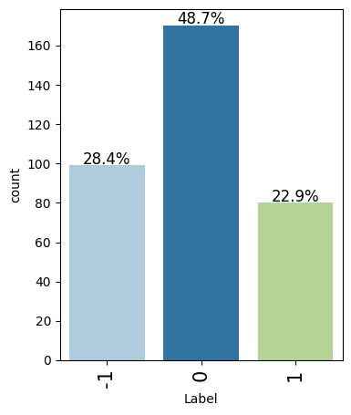

```python
labeled_barplot(data, "Label", perc=True)
```

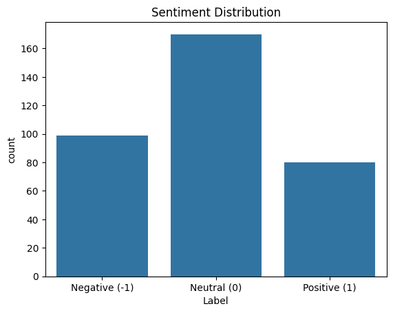

```python
sns.countplot(data=data, x='Label')
plt.title("Sentiment Distribution")
plt.xticks(ticks=[0, 1, 2], labels=["Negative (-1)", "Neutral (0)", "Positive (1)"])
plt.show()
```

#### StockPricesTrendOverTime

```python
def multi_price_line_plot(data):

    data['Date'] = pd.to_datetime(data['Date'])
    data = data.sort_values('Date')

    fig, ax = plt.subplots(figsize=(14, 7))
    for col in ['Open','High','Low','Close']:
        sns.lineplot(data=data, x='Date', y=col, ax=ax, label=col)

    ax.set_title("Stock Price Trends Over Time")
    ax.set_xlabel("Date")
    ax.set_ylabel("Price ($)")
    plt.xticks(rotation=45)
    plt.legend()
    plt.tight_layout()
    plt.show()
```

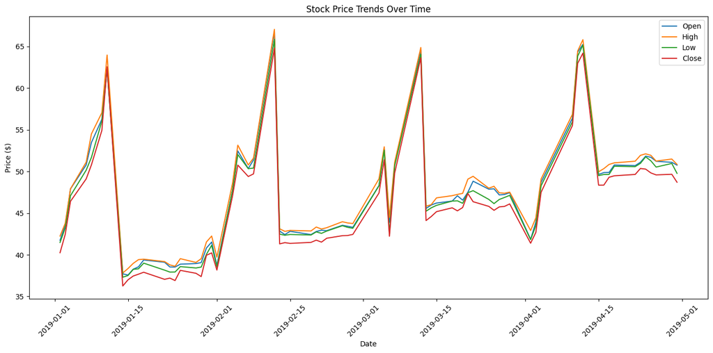

```python
multi_price_line_plot(data)
```

- Stock price fluctuations show market Volatility contributing to certain major events, also the consistent increase or decrease is indicative of certain market sentiments.
- The close,high,low trends are very close during periods which shows investors confidence or uncertainty related to market sentiments and miminal daily variance during thise periods implying steady market conditions in those periods.

[figure not shown]

```python
#Line plot of Volume vs Date
plt.plot(data['Date'], data['Close'])
plt.title("Volume Traded  Over Time")
plt.xlabel("Date")
plt.xticks(rotation=45)
plt.ylabel("Volume")
plt.show()
```

#### Distribution - stock prices -High, low,Open and close

```
             Open        High         Low       Close
count  349.000000  349.000000  349.000000  349.000000
mean    46.229233   46.700458   45.745394   44.926317
std      6.442817    6.507321    6.391976    6.398338
min     37.567501   37.817501   37.305000   36.254131
25%     41.740002   42.244999   41.482498   40.246914
50%     45.974998   46.025002   45.639999   44.596924
75%     50.707500   50.849998   49.777500   49.110790
max     66.817497   67.062500   65.862503   64.805229
```

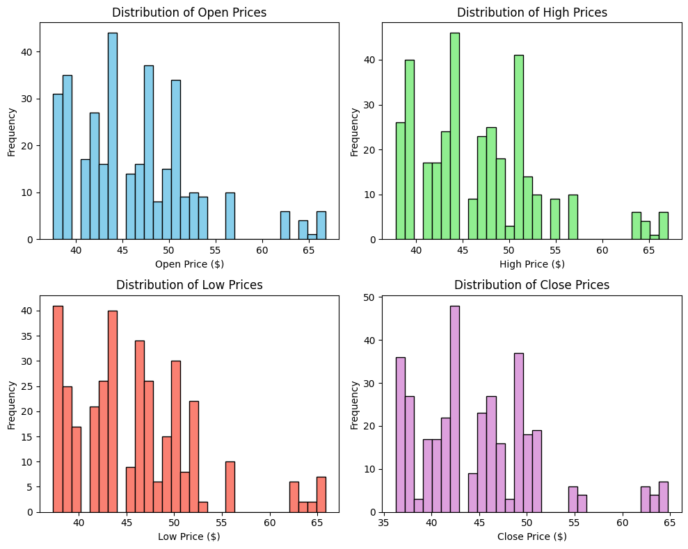

```python
# Summary statistics
print(data[['Open', 'High', 'Low', 'Close']].describe())

# Columns to plot
cols = ['Open', 'High', 'Low', 'Close']
colors = ['skyblue', 'lightgreen', 'salmon', 'plum']

# Create 2x2 subplot grid
fig, axs = plt.subplots(2, 2, figsize=(10, 8))

# Plot each histogram
for i, col in enumerate(cols):
    row = i // 2
    col_index = i % 2
    axs[row, col_index].hist(data[col], bins=30, color=colors[i], edgecolor='black')
    axs[row, col_index].set_title(f'Distribution of {col} Prices')
    axs[row, col_index].set_xlabel(f'{col} Price ($)')
    axs[row, col_index].set_ylabel('Frequency')

# Adjust layout
plt.tight_layout()
plt.show()
```

- The distributions of Open, Low,HIgh,close show a relatively stable range with most stocks $40-$50.
- We can also see High price distribution closely matching to Open and close prices , showing stability in the daily price patterns.

#### Distribution - Length of News

```python
# Compute the length of each news article (in characters)
data['News_Length'] = data['News'].str.len()
```

```python
# Summary statistics
summary_stats = data['News_Length'].describe()
print("Summary Statistics:")
print(summary_stats)
```

```
Summary Statistics:
count    349.000000
mean     311.237822
std       39.079467
min      110.000000
25%      290.000000
50%      315.000000
75%      336.000000
max      394.000000
Name: News_Length, dtype: float64
```

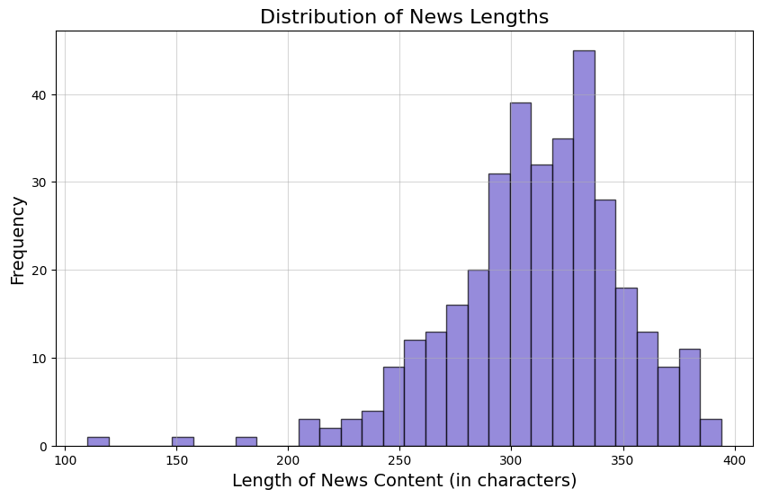

```python
# Plotting the distribution
plt.figure(figsize=(10, 6))
plt.hist(data['News_Length'], bins=30, color='slateblue', edgecolor='black', alpha=0.7)
plt.title('Distribution of News Lengths', fontsize=16)
plt.xlabel('Length of News Content (in characters)', fontsize=14)
plt.ylabel('Frequency', fontsize=14)
plt.grid(alpha=0.5)
plt.show()
```

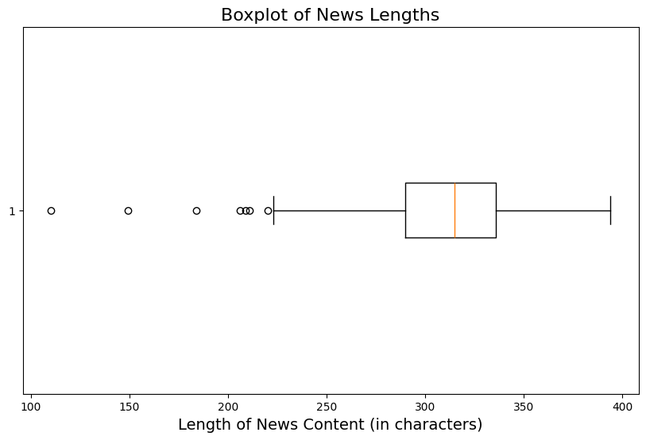

```python
plt.figure(figsize=(10, 6))
plt.boxplot(data['News_Length'], vert=False)
plt.title('Boxplot of News Lengths', fontsize=16)
plt.xlabel('Length of News Content (in characters)', fontsize=14)
plt.show()
```

- Most News have length between 250-350 characters with median around 300 characters
- There are a few outliers beloww 200 characters, but overall it is a well defined distribution
- The average New length of 311 is a good inicator to select max token legth of LLM or transformer input.

### Bivariate Analysis

- Correlation
- Sentiment Polarity vs Price
- Date vs Price

**Note**: The above points are listed to provide guidance on how to approach bivariate analysis. Analysis has to be done beyond the above listed points to get maximum scores.

#### Co-Relations

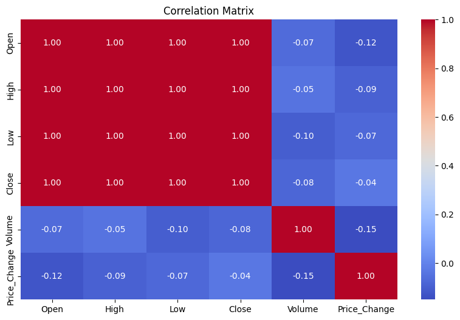

```python
#Heatmap
#Create a Prie Change Column
data['Price_Change'] = data['Close'] - data['Open']

# Select numerical columns
corr_cols = ['Open', 'High', 'Low', 'Close', 'Volume','Price_Change']
corr_matrix = data[corr_cols].corr()

# Plot heatmap
plt.figure(figsize=(10, 6))
sns.heatmap(corr_matrix, annot=True, cmap='coolwarm', fmt='.2f')
plt.title("Correlation Matrix")
plt.show()
```

- Stock Proces show a perfect co-relation showing that these move togethere reflecting intraday less variance
- Slight Negative co-relation between volume and stock prices(-0.07 to -0.1) indicating minor impact resulting in higher trading volume on perios of lower prices or market volatility.
- This overall indicates less influence of Volume and Price Changes and strong dependencies among Stock price metrics

#### Sentiment vs Stock Price Movement

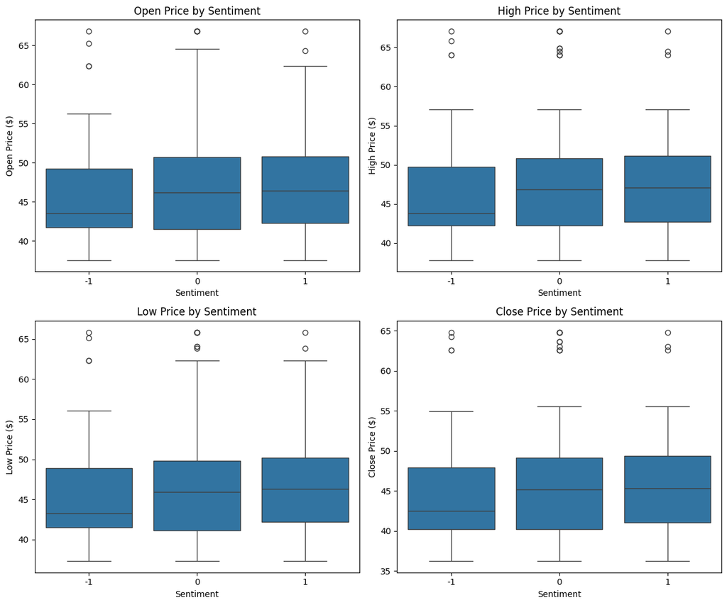

```python
# List of price columns to plot
price_cols = ['Open', 'High', 'Low', 'Close']
sentiment_labels = ["Negative", "Neutral", "Positive"]

# Create 2x2 subplot grid
fig, axs = plt.subplots(2, 2, figsize=(12, 10))

# Flatten axes array for easy iteration
axs = axs.flatten()

# Plot each boxplot
for i, col in enumerate(price_cols):
    sns.boxplot(data=data, x='Label', y=col, ax=axs[i])
    axs[i].set_title(f'{col} Price by Sentiment')
    axs[i].set_xlabel("Sentiment")
    axs[i].set_ylabel(f'{col} Price ($)')
plt.tight_layout()
plt.show()
```

- We can see that positive sentiments correlate with higher stock proces across all metrics, netural sentiment steady and negative sentiments with lower prices
- Stock prices concentrated between 40 and 50$ showing stability in trading.

#### Sentiment vs Volume Traded

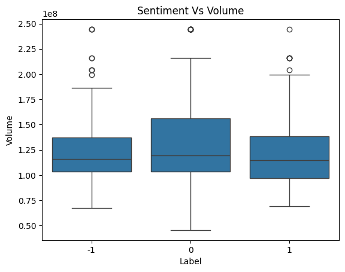

```python
#Boxplot of Volume grouped by Label
sns.boxplot(data=data, x='Label', y='Volume')
plt.title("Sentiment Vs Volume")
plt.show()
```

#### Daily Price Change vs Sentiment

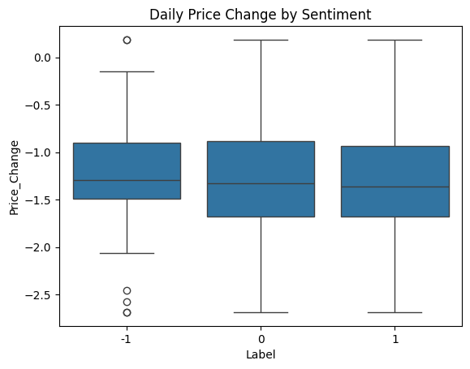

```python
#Plot of Price_Change by Label by creating a A new column Price_Change = Close - Open and
sns.boxplot(data=data, x='Label', y='Price_Change')
plt.title("Daily Price Change by Sentiment")
plt.show()
```

- Stock prices generally declined across all sentiment labels, indicating sentiment alone may not drive immediate price change. Notably, negative news showed more outliers, suggesting unpredictable market responses.

```python
#Reset column changes in EDA before moving to ML building
data=reviews.copy()
```

```python
data.head()
```

|  | Date | News | Open | High | Low | Close | Volume | Label |
| --- | --- | --- | --- | --- | --- | --- | --- | --- |
| 0 | 2019-01-02 | The tech sector experienced a significant decline in the aftermarket following Apple's Q1 revenue warning. Notable suppliers, including Skyworks, Broadcom, Lumentum, Qorvo, and TSMC, saw their stocks … | 41.740002 | 42.244999 | 41.482498 | 40.246914 | 130672400 | -1 |
| 1 | 2019-01-02 | Apple lowered its fiscal Q1 revenue guidance to $84 billion from earlier estimates of $89-$93 billion due to weaker than expected iPhone sales. The announcement caused a significant drop in Apple's st… | 41.740002 | 42.244999 | 41.482498 | 40.246914 | 130672400 | -1 |
| 2 | 2019-01-02 | Apple cut its fiscal first quarter revenue forecast from $89-$93 billion to $84 billion due to weaker demand in China and fewer iPhone upgrades. CEO Tim Cook also mentioned constrained sales of Airpod… | 41.740002 | 42.244999 | 41.482498 | 40.246914 | 130672400 | -1 |
| 3 | 2019-01-02 | This news article reports that yields on long-dated U.S. Treasury securities hit their lowest levels in nearly a year on January 2, 2019, due to concerns about the health of the global economy followi… | 41.740002 | 42.244999 | 41.482498 | 40.246914 | 130672400 | -1 |
| 4 | 2019-01-02 | Apple's revenue warning led to a decline in USD JPY pair and a gain in Japanese yen, as investors sought safety in the highly liquid currency. Apple's underperformance in Q1, with forecasted revenue o… | 41.740002 | 42.244999 | 41.482498 | 40.246914 | 130672400 | -1 |

## **Text Preprocessing**

```python
#Text PreProcessing functions
import contractions
# Loading the Porter Stemmer
ps = PorterStemmer()

#function to fix contractions
def fix_contractions(text):
 text = contractions.fix(text)
 return text

 # defining a function to remove special characters
def remove_special_characters(text):
    # Defining the regex pattern to match non-alphanumeric characters
    pattern = '[^A-Za-z0-9]+'

    # Finding the specified pattern and replacing non-alphanumeric characters with a blank string
    new_text = ''.join(re.sub(pattern, ' ', text))

    return new_text

 # defining a function to remove stop words using the NLTK library
def remove_stopwords(text):
    # Split text into separate words
    words = text.split()

    # Removing English language stopwords
    new_text = ' '.join([word for word in words if word not in stopwords.words('english')])

    return new_text

# defining a function to perform stemming
def apply_porter_stemmer(text):
    # Split text into separate words
    words = text.split()

    # Applying the Porter Stemmer on every word of a message and joining the stemmed words back into a single string
    new_text = ' '.join([ps.stem(word) for word in words])

    return new_text
```

```python
data['News'] = data['News'].apply(fix_contractions)

# Applying the function to remove special characters
data['News'] = data['News'].apply(remove_special_characters)

# changing the case of the text data to lower case
data['News'] = data['News'].str.lower()

# removing extra whitespaces from the text
data['News'] = data['News'].str.strip()

# Applying the function to remove stop words using the NLTK library
data['News'] = data['News'].apply(remove_stopwords)

# Applying the function to perform stemming
data['News'] = data['News'].apply(apply_porter_stemmer)
```

```python
data.head()
```

|  | Date | News | Open | High | Low | Close | Volume | Label |
| --- | --- | --- | --- | --- | --- | --- | --- | --- |
| 0 | 2019-01-02 | tech sector experienc signific declin aftermarket follow appl q1 revenu warn notabl supplier includ skywork broadcom lumentum qorvo tsmc saw stock drop respons appl downward revis revenu expect quarte… | 41.740002 | 42.244999 | 41.482498 | 40.246914 | 130672400 | -1 |
| 1 | 2019-01-02 | appl lower fiscal q1 revenu guidanc 84 billion earlier estim 89 93 billion due weaker expect iphon sale announc caus signific drop appl stock price neg impact relat supplier lead broader market declin… | 41.740002 | 42.244999 | 41.482498 | 40.246914 | 130672400 | -1 |
| 2 | 2019-01-02 | appl cut fiscal first quarter revenu forecast 89 93 billion 84 billion due weaker demand china fewer iphon upgrad ceo tim cook also mention constrain sale airpod macbook appl share fell 8 5 post marke… | 41.740002 | 42.244999 | 41.482498 | 40.246914 | 130672400 | -1 |
| 3 | 2019-01-02 | news articl report yield long date treasuri secur hit lowest level nearli year januari 2 2019 due concern health global economi follow weak econom data china europ well partial govern shutdown appl | 41.740002 | 42.244999 | 41.482498 | 40.246914 | 130672400 | -1 |
| 4 | 2019-01-02 | appl revenu warn led declin usd jpi pair gain japanes yen investor sought safeti highli liquid currenc appl underperform q1 forecast revenu 84 billion compar analyst expect 91 5 billion trigger risk a… | 41.740002 | 42.244999 | 41.482498 | 40.246914 | 130672400 | -1 |

## Word Embeddings

### **Word2Vec**

```python
# Creating a list of all words in our data
words_list = [item.split(" ") for item in data['News'].values]
```

```python
# Creating an instance of Word2Vec
vec_size = 100
model_W2V = Word2Vec(words_list, vector_size = vec_size, min_count = 1, window=5, workers = 6)
```

```python
# Checking the size of the vocabulary
print("Length of the vocabulary is", len(list(model_W2V.wv.key_to_index)))
```

```
Length of the vocabulary is 2579
```

```python
# Checking the word embedding of a random word
word = "stock"
model_W2V.wv[word]
```

```
array([-1.47340717e-02,  2.17218772e-02,  4.67196456e-04, -2.56367121e-03,
        1.04516605e-02, -3.13654467e-02,  4.99718962e-03,  4.67559248e-02,
       -2.03256477e-02, -6.30829530e-03, -1.67972855e-02, -3.29953730e-02,
        7.18688266e-03,  5.57762943e-03,  9.76747181e-03, -2.56844833e-02,
        1.11779431e-02, -1.68428589e-02, -9.65287071e-03, -4.74666357e-02,
        7.30755460e-03,  6.14891108e-03,  5.40890219e-03, -1.70389339e-02,
        3.80788278e-03, -4.89361165e-03, -9.97730438e-03, -1.12799397e-02,
       -2.65616886e-02,  1.06728142e-02,  3.06618344e-02, -4.50134603e-03,
        3.82465281e-04, -1.62669737e-02, -1.83871724e-02,  2.59705279e-02,
        1.12158712e-03, -1.78649724e-02, -9.59948264e-03, -4.65081036e-02,
       -3.25852004e-03, -1.63308196e-02, -6.67917030e-03,  7.62332464e-03,
        2.30773669e-02, -4.76464769e-03, -1.02223447e-02,  9.61823025e-05,
        4.53953771e-03,  1.55586228e-02,  1.24203330e-02, -1.77081246e-02,
       -1.44536160e-02, -9.33006406e-03, -2.06921473e-02,  6.17860677e-03,
        1.30839171e-02, -5.36582759e-03, -3.06403562e-02, -1.59069255e-03,
        9.78046097e-03,  2.73320312e-03, -1.40741316e-03, -4.01417492e-03,
       -4.09114249e-02,  3.19448449e-02,  1.87904462e-02,  2.56493352e-02,
       -3.83287072e-02,  3.39594334e-02, -9.72121302e-03,  1.53264524e-02,
        3.03887594e-02, -6.16740342e-03,  2.25104038e-02,  2.08331384e-02,
        1.20384889e-02, -3.50611960e-03, -2.38052774e-02,  8.82241223e-03,
       -1.30661428e-02, -1.09843295e-02, -2.71061826e-02,  3.62369753e-02,
        2.78648199e-03, -5.79357380e-03, -5.58341620e-03,  2.31853928e-02,
        3.31811383e-02,  9.61801969e-03,  2.01235823e-02,  1.51540423e-02,
        1.12930462e-02,  3.16673494e-03,  4.60428111e-02,  2.61532702e-02,
        1.65056307e-02, -1.57919023e-02,  1.57123264e-02, -1.57725960e-02],
      dtype=float32)
```

```python
# Checking top 5 similar words to the word 'stock'
similar = model_W2V.wv.similar_by_word('stock', topn=5)
print(similar)
```

```
[('compani', 0.9359973669052124), ('appl', 0.9347637295722961), ('trade', 0.9269189834594727), ('sale', 0.9132720828056335), ('due', 0.9131594896316528)]
```

```python
# Retrieving the words present in the Word2Vec model's vocabulary
words = list(model_W2V.wv.key_to_index.keys())

# Retrieving word vectors for all the words present in the model's vocabulary
wvs = model_W2V.wv[words].tolist()

# Creating a dictionary of words and their corresponding vectors
word_vector_dict = dict(zip(words, wvs))
```

```python
def average_vectorizer_Word2Vec(doc):
    # Initializing a feature vector for the sentence
    feature_vector = np.zeros((vec_size,), dtype="float64")

    # Creating a list of words in the sentence that are present in the model vocabulary
    words_in_vocab = [word for word in doc.split() if word in words]

    # adding the vector representations of the words
    for word in words_in_vocab:
        feature_vector += np.array(word_vector_dict[word])

    # Dividing by the number of words to get the average vector
    if len(words_in_vocab) != 0:
        feature_vector /= len(words_in_vocab)

    return feature_vector
```

```python
# creating a dataframe of the vectorized documents
df_Word2Vec = pd.DataFrame(data['News'].apply(average_vectorizer_Word2Vec).tolist(), columns=['Feature '+str(i) for i in range(vec_size)])
df_Word2Vec
```

|  | Feature 0 | Feature 1 | Feature 2 | Feature 3 | Feature 4 | Feature 5 | Feature 6 | Feature 7 | Feature 8 | Feature 9 | ... | Feature 90 | Feature 91 | Feature 92 | Feature 93 | Feature 94 | Feature 95 | Feature 96 | Feature 97 | Feature 98 | Feature 99 |
| --- | --- | --- | --- | --- | --- | --- | --- | --- | --- | --- | --- | --- | --- | --- | --- | --- | --- | --- | --- | --- | --- |
| 0 | -0.008994 | 0.009056 | 0.003485 | 0.000403 | -0.000693 | -0.020424 | 0.005584 | 0.023124 | -0.006767 | -0.008985 | ... | 0.013424 | 0.005712 | 0.001486 | 0.003496 | 0.020646 | 0.011584 | 0.004472 | -0.009324 | 0.004509 | -0.005023 |
| 1 | -0.009808 | 0.011599 | 0.004551 | 0.001181 | -0.000675 | -0.022590 | 0.006644 | 0.027432 | -0.007374 | -0.009335 | ... | 0.014321 | 0.006170 | 0.000390 | 0.004026 | 0.023134 | 0.011728 | 0.004989 | -0.009173 | 0.006080 | -0.004581 |
| 2 | -0.008821 | 0.009730 | 0.005368 | 0.001507 | 0.000949 | -0.021285 | 0.006104 | 0.025177 | -0.006373 | -0.008795 | ... | 0.014247 | 0.004884 | -0.001133 | 0.004329 | 0.020825 | 0.010603 | 0.005210 | -0.008300 | 0.004455 | -0.005184 |
| 3 | -0.007321 | 0.010781 | 0.004330 | -0.002503 | -0.001082 | -0.020258 | 0.003498 | 0.024012 | -0.007223 | -0.007735 | ... | 0.012762 | 0.004152 | -0.000213 | 0.002378 | 0.020210 | 0.009271 | 0.004992 | -0.010334 | 0.003698 | -0.003001 |
| 4 | -0.006105 | 0.008662 | 0.003116 | 0.001101 | 0.000941 | -0.017145 | 0.005157 | 0.019560 | -0.005883 | -0.007291 | ... | 0.011272 | 0.005355 | 0.000381 | 0.002912 | 0.017202 | 0.008824 | 0.004941 | -0.006689 | 0.003919 | -0.004481 |
| ... | ... | ... | ... | ... | ... | ... | ... | ... | ... | ... | ... | ... | ... | ... | ... | ... | ... | ... | ... | ... | ... |
| 344 | -0.004792 | 0.003164 | 0.002494 | -0.001959 | 0.001702 | -0.009006 | -0.000196 | 0.008161 | -0.000776 | -0.003465 | ... | 0.004744 | 0.003080 | 0.000035 | 0.000989 | 0.006015 | 0.002549 | 0.003619 | -0.003532 | 0.002662 | -0.001021 |
| 345 | -0.004216 | 0.008440 | 0.001754 | -0.000143 | 0.001227 | -0.012337 | 0.002792 | 0.015872 | -0.005929 | -0.004402 | ... | 0.008510 | 0.004203 | 0.001186 | 0.002195 | 0.012835 | 0.007201 | 0.002994 | -0.007274 | 0.003744 | -0.002697 |
| 346 | -0.006961 | 0.009740 | 0.002903 | -0.000747 | 0.000870 | -0.015781 | 0.007029 | 0.018070 | -0.005135 | -0.005554 | ... | 0.009524 | 0.003625 | 0.001822 | 0.002456 | 0.017552 | 0.006502 | 0.005296 | -0.006347 | 0.002113 | -0.003836 |
| 347 | -0.009144 | 0.007808 | 0.003836 | -0.000509 | 0.000376 | -0.018563 | 0.003216 | 0.021151 | -0.005390 | -0.005990 | ... | 0.011322 | 0.004081 | 0.001211 | 0.006015 | 0.019151 | 0.010887 | 0.004810 | -0.006563 | 0.003641 | -0.003370 |
| 348 | -0.009416 | 0.007459 | 0.002014 | -0.000728 | 0.001716 | -0.017835 | 0.003560 | 0.021455 | -0.005312 | -0.007217 | ... | 0.013948 | 0.003522 | -0.001176 | 0.003273 | 0.015806 | 0.009051 | 0.004856 | -0.006094 | 0.002480 | -0.002783 |

349 rows × 100 columns

### **GloVe**

```python
# load the Stanford GloVe model
filename = '/content/drive/MyDrive/Python/glove.6B.100d.txt.word2vec'
glove_model = KeyedVectors.load_word2vec_format(filename, binary=False)
```

```python
# Checking the size of the vocabulary
print("Length of the vocabulary is", len(glove_model.index_to_key))
```

```
Length of the vocabulary is 400000
```

```python
# Checking the word embedding of a random word
word = "stock"
glove_model[word]
```

```
array([ 8.6341e-01,  6.9648e-01,  4.5794e-02, -9.5708e-03, -2.5498e-01,
       -7.4666e-01, -2.2086e-01, -4.4615e-01, -1.0423e-01, -9.9931e-01,
        7.2550e-02,  4.5049e-01, -5.9912e-02, -5.7837e-01, -4.6540e-01,
        4.3429e-02, -5.0570e-01, -1.5442e-01,  9.8250e-01, -8.1571e-02,
        2.6523e-01, -2.3734e-01,  9.7675e-02,  5.8588e-01, -1.2948e-01,
       -6.8956e-01, -1.2811e-01, -5.2265e-02, -6.7719e-01,  3.0190e-02,
        1.8058e-01,  8.6121e-01, -8.3206e-01, -5.6887e-02, -2.9578e-01,
        4.7180e-01,  1.2811e+00, -2.5228e-01,  4.9557e-02, -7.2455e-01,
        6.6758e-01, -1.1091e+00, -2.0493e-01, -5.8669e-01, -2.5375e-03,
        8.2777e-01, -4.9102e-01, -2.6475e-01,  4.3015e-01, -2.0516e+00,
       -3.3208e-01,  5.1845e-02,  5.2646e-01,  8.7452e-01, -9.0237e-01,
       -1.7366e+00, -3.4727e-01,  1.6590e-01,  2.7727e+00,  6.5756e-02,
       -4.0363e-01,  3.8252e-01, -3.0787e-01,  5.9202e-01,  1.3468e-01,
       -3.3851e-01,  3.3646e-01,  2.0950e-01,  8.5905e-01,  5.1865e-01,
       -1.0657e+00, -2.6371e-02, -3.1349e-01,  2.3231e-01, -7.0192e-01,
       -5.5737e-01, -2.3418e-01,  1.3563e-01, -1.0016e+00, -1.4221e-01,
        1.0372e+00,  3.5880e-01, -4.2608e-01, -1.9386e-01, -3.7867e-01,
       -6.9646e-01, -3.9989e-01, -5.7782e-01,  1.0132e-01,  2.0123e-01,
       -3.7153e-01,  5.0837e-01, -3.7758e-01, -2.6205e-01, -9.3676e-01,
        1.0053e+00,  8.4393e-01, -2.4698e-01,  1.7339e-01,  9.4473e-01],
      dtype=float32)
```

```python
result = glove_model.most_similar("stock", topn=5)
print(result)
```

```
[('shares', 0.8525474667549133), ('stocks', 0.8309943079948425), ('market', 0.7991610765457153), ('exchange', 0.784952700138092), ('trading', 0.7632874846458435)]
```

```python
# Retrieving the words present in the GloVe model's vocabulary
glove_words = glove_model.index_to_key

# Creating a dictionary of words and their corresponding vectors
glove_word_vector_dict = dict(zip(glove_model.index_to_key,list(glove_model.vectors)))
```

```python
vec_size=100
```

```python
def average_vectorizer_GloVe(doc):
    # Initializing a feature vector for the sentence
    feature_vector = np.zeros((vec_size,), dtype="float64")

    # Creating a list of words in the sentence that are present in the model vocabulary
    words_in_vocab = [word for word in doc.split() if word in glove_words]

    # adding the vector representations of the words
    for word in words_in_vocab:
        feature_vector += np.array(glove_word_vector_dict[word])

    # Dividing by the number of words to get the average vector
    if len(words_in_vocab) != 0:
        feature_vector /= len(words_in_vocab)

    return feature_vector
```

```python
# creating a dataframe of the vectorized documents
df_Glove = pd.DataFrame(data['News'].apply(average_vectorizer_GloVe).tolist(), columns=['Feature '+str(i) for i in range(vec_size)])
df_Glove
```

|  | Feature 0 | Feature 1 | Feature 2 | Feature 3 | Feature 4 | Feature 5 | Feature 6 | Feature 7 | Feature 8 | Feature 9 | ... | Feature 90 | Feature 91 | Feature 92 | Feature 93 | Feature 94 | Feature 95 | Feature 96 | Feature 97 | Feature 98 | Feature 99 |
| --- | --- | --- | --- | --- | --- | --- | --- | --- | --- | --- | --- | --- | --- | --- | --- | --- | --- | --- | --- | --- | --- |
| 0 | 0.021671 | 0.096785 | -0.047464 | -0.066726 | -0.215078 | -0.603108 | -0.089054 | -0.001979 | 0.114239 | -0.132121 | ... | -0.016118 | 0.282037 | -0.146394 | -0.217284 | -0.137730 | 0.162514 | 0.208869 | 0.056668 | 0.186156 | -0.025540 |
| 1 | 0.171825 | 0.341351 | 0.234650 | -0.042054 | -0.082840 | -0.600302 | -0.060674 | -0.101788 | -0.159387 | 0.023604 | ... | 0.001762 | 0.271578 | -0.190244 | -0.136070 | -0.442046 | 0.225178 | 0.175980 | -0.036701 | 0.410090 | -0.159631 |
| 2 | 0.010512 | 0.270341 | 0.301482 | -0.087113 | 0.075485 | -0.476547 | -0.039534 | -0.014161 | -0.123561 | -0.054536 | ... | 0.113562 | 0.199301 | -0.095302 | -0.220799 | -0.559601 | 0.130351 | 0.039756 | -0.088995 | 0.484577 | -0.204774 |
| 3 | -0.156355 | 0.227387 | 0.371944 | 0.127959 | -0.104669 | -0.487158 | -0.136592 | 0.015587 | -0.035610 | -0.069212 | ... | 0.042797 | 0.276621 | -0.277062 | 0.001116 | -0.380228 | 0.195987 | 0.202714 | -0.186087 | 0.334680 | -0.061315 |
| 4 | 0.040798 | 0.198312 | 0.071460 | 0.037332 | -0.098294 | -0.407203 | -0.078844 | -0.102327 | -0.132380 | -0.031861 | ... | 0.041134 | 0.188611 | -0.051261 | -0.364269 | -0.216124 | 0.242409 | 0.243280 | -0.071136 | 0.173813 | -0.131392 |
| ... | ... | ... | ... | ... | ... | ... | ... | ... | ... | ... | ... | ... | ... | ... | ... | ... | ... | ... | ... | ... | ... |
| 344 | -0.133417 | 0.058861 | 0.415255 | -0.291097 | 0.051498 | 0.079182 | 0.057609 | 0.127537 | -0.074177 | -0.070428 | ... | 0.306373 | -0.166262 | 0.083386 | -0.120771 | -0.347820 | 0.049615 | -0.054991 | -0.299478 | 0.437251 | 0.188692 |
| 345 | 0.159967 | 0.246612 | 0.288849 | 0.093632 | 0.043483 | -0.284527 | -0.167188 | -0.049947 | -0.246812 | -0.088806 | ... | 0.042174 | 0.246746 | -0.054319 | -0.047361 | -0.572373 | 0.368322 | 0.077437 | 0.020181 | 0.441181 | 0.015956 |
| 346 | 0.043433 | 0.127144 | 0.151791 | -0.053902 | -0.067352 | -0.187623 | -0.020754 | 0.138385 | -0.354622 | -0.084654 | ... | -0.066027 | 0.240859 | -0.119884 | -0.026659 | -0.428011 | 0.054745 | -0.025141 | -0.129436 | 0.258558 | -0.027775 |
| 347 | -0.098248 | 0.090049 | 0.181622 | -0.028409 | -0.128997 | -0.497643 | -0.247336 | -0.034014 | -0.103773 | -0.195073 | ... | 0.012848 | 0.070933 | -0.053851 | -0.265540 | -0.415342 | 0.111974 | 0.295720 | -0.207213 | 0.378713 | 0.026234 |
| 348 | 0.066789 | 0.339016 | 0.296032 | -0.123497 | -0.115996 | -0.460525 | 0.035026 | 0.121192 | -0.158255 | -0.070437 | ... | -0.013131 | 0.204805 | -0.259545 | 0.037068 | -0.419796 | 0.014846 | 0.085902 | -0.183811 | 0.634333 | -0.208610 |

349 rows × 100 columns

### **Sentence-Transformer**

```python
# to load transformer models
from sentence_transformers import SentenceTransformer
from transformers import T5Tokenizer, T5ForConditionalGeneration, pipeline
```

```python
# defining the model
model = SentenceTransformer('sentence-transformers/all-MiniLM-L6-v2')
```

[output not shown]

```python
# setting the device to GPU if available, else CPU
device = torch.device("cuda" if torch.cuda.is_available() else "cpu")
```

```python
# encoding the dataset
embedding_matrix = model.encode(data['News'], device=device, show_progress_bar=True)
```

```python
# printing the shape of the embedding matrix
embedding_matrix.shape
```

```
(349, 384)
```

```python
# printing the embedding vector of the first News in the dataset
embedding_matrix[0,:]
```

[output not shown]

[output cut: 42 more lines]

[output not shown]

- search for similar reviews in our dataset

```python
# defining a function to find the top k similar sentences for a given query
def top_k_similar_sentences(embedding_matrix,query_text,k):
    # encoding the query text
    query_embedding = model.encode(query_text)

    # calculating the cosine similarity between the query vector and all other encoded vectors of our dataset
    score_vector = np.dot(embedding_matrix,query_embedding)

    # sorting the scores in descending order and choosing the first k
    top_k_indices = np.argsort(score_vector)[::-1][:k]

    # returning the corresponding reviews
    return data.loc[list(top_k_indices), 'News']
```

```python
# defining the query text
query_text = "stock"

# displaying the top 5 similar sentences
top_k_reviews = top_k_similar_sentences(embedding_matrix,query_text,5)

for i in top_k_reviews:
    print(i, end="\n\n")
```

```
appl nasdaq aapl stock declin 0 52 premarket trade friday due price cut iphon model china compani set launch three new iphon model year johnson johnson nyse jnj stock edg forward rais prescript drug price starbuck

premarket trade tuesday appl nasdaq aapl stock decreas 0 15 due price cut china amazon nasdaq amzn stock rose 0 2 follow price reduct whole food store lyft nasdaq lyft

oracl stock declin 8 15 premarket trade ceo safra catz warn potenti revenu drop 2 billion current quarter mark fourth consecut quarterli declin due challeng cloud servic growth

tech sector experienc signific declin aftermarket follow appl q1 revenu warn notabl supplier includ skywork broadcom lumentum qorvo tsmc saw stock drop respons appl downward revis revenu expect quarter previous announc januari

tuesday trade dow p 500 nasdaq rose tech stock surg led netflix price increas jpmorgan rebound weak earn well fargo struggl mix result continu regulatori scrutini stimulu measur china eas investor concern
```

```python
# Set vector size based on the model's output dimension
vec_size = embedding_matrix.shape[1]

# Create DataFrame from the embedding matrix
df_SentenceTransformer = pd.DataFrame(
    embedding_matrix,
    columns=['Feature ' + str(i) for i in range(vec_size)]
)
```

```python
df_SentenceTransformer.head()
```

|  | Feature 0 | Feature 1 | Feature 2 | Feature 3 | Feature 4 | Feature 5 | Feature 6 | Feature 7 | Feature 8 | Feature 9 | ... | Feature 374 | Feature 375 | Feature 376 | Feature 377 | Feature 378 | Feature 379 | Feature 380 | Feature 381 | Feature 382 | Feature 383 |
| --- | --- | --- | --- | --- | --- | --- | --- | --- | --- | --- | --- | --- | --- | --- | --- | --- | --- | --- | --- | --- | --- |
| 0 | -0.043523 | -0.032950 | 0.011877 | -0.028118 | -0.049230 | -0.032252 | 0.064922 | 0.085961 | -0.005158 | -0.007017 | ... | -0.037028 | -0.022111 | -0.046661 | 0.017057 | -0.092947 | -0.017295 | 0.013881 | -0.094793 | 0.001821 | 0.049449 |
| 1 | -0.046315 | -0.010828 | 0.026855 | -0.015553 | -0.069605 | -0.013317 | 0.029792 | 0.103048 | 0.062170 | 0.024213 | ... | 0.028121 | 0.046966 | -0.079598 | 0.041040 | -0.061292 | -0.032827 | 0.067067 | -0.089966 | 0.020078 | 0.019576 |
| 2 | -0.026371 | -0.011947 | 0.086375 | 0.021910 | -0.000371 | -0.001986 | 0.003526 | 0.003866 | 0.019243 | 0.058253 | ... | 0.026390 | 0.053179 | -0.047150 | -0.029262 | -0.043121 | -0.045363 | 0.036033 | -0.078585 | -0.034786 | 0.124454 |
| 3 | -0.015118 | 0.035373 | 0.008511 | 0.038934 | -0.029335 | -0.036515 | -0.060357 | 0.095957 | -0.030932 | 0.022067 | ... | 0.018480 | 0.063605 | -0.060921 | 0.024456 | -0.061559 | -0.009413 | 0.078051 | -0.057378 | -0.021433 | 0.097374 |
| 4 | -0.062147 | 0.008860 | -0.046556 | 0.031366 | -0.032564 | 0.005758 | 0.078128 | 0.103136 | 0.028486 | -0.034042 | ... | 0.038222 | 0.012146 | -0.057044 | 0.012866 | -0.009461 | 0.021578 | 0.061312 | -0.130987 | -0.065216 | 0.008981 |

5 rows × 384 columns

## DataPreProcessing

```python
#Splitting the target variables and predictors and split in train, validation and test sets
X_word2vec = df_Word2Vec.copy()
X_glove = df_Glove.copy()
X_sentence = df_SentenceTransformer
y = data['Label']
```

```python
#Function to define split
def split(X,y):
    # Initial split into training (80%) and testing (20%)
    X_train, X_temp, y_train, y_temp = train_test_split(X, y, test_size=0.20, stratify=y, random_state=42)

    # Further split the temporary set into validation (10%) and test (10%) sets
    X_valid, X_test, y_valid, y_test = train_test_split(X_temp, y_temp, test_size=0.50, stratify=y_temp, random_state=42)

    return X_train,X_valid,X_test,y_train,y_valid,y_test
```

```python
X_train_word2vec,X_valid_word2vec,X_test_word2vec,y_train_word2vec,y_valid_word2vec,y_test_word2vec=split(X_word2vec,y)
X_train_glove,X_valid_glove,X_test_glove,y_train_glove,y_valid_glove,y_test_glove=split(X_glove,y)
X_train_sentence,X_valid_sentence,X_test_sentence,y_train_sentence,y_valid_sentence,y_test_sentence=split(X_sentence,y)
```

## **Sentiment Analysis**

**Model Evaluation Criteria**

We will be building Randome Forest Models for the various embeddings below. Since there is multiclass imbalance in our data, the approach will be to evaluate the following three pamaters and use a combination of three to deteremine the best model:

1. Accuracy : Determining overall correctness
2. F1 Score (both macro & weighted) - to establish a balance amongs Recall and F1 score across classed
3. Confusion Matrix : To determine Class wise performance.

However, given the very small dataset and highly imbalanced classes,we need to be aware that these outcomes will not truely be deterministic,

```python
#Defining a function to plot confusion matrix
def confusion_matrix_sklearn(model, predictors, target):
    """
    To plot the confusion_matrix with percentages

    model: classifier
    predictors: independent variables
    target: dependent variable
    """
    y_pred = model.predict(predictors)
    cm = confusion_matrix(target, y_pred)
    labels = np.asarray(
        [
            ["{0:0.0f}".format(item) + "\n{0:.2%}".format(item / cm.flatten().sum())]
            for item in cm.flatten()
        ]
    ).reshape(cm.shape[0], cm.shape[1])

    plt.figure(figsize=(6, 4))
    sns.heatmap(cm, annot=labels, fmt="", xticklabels=["-1", "0", "1"], yticklabels=["-1", "0", "1"])
    plt.ylabel("True label")
    plt.xlabel("Predicted label")
```

### RFModel-base-Word2Vec

```python
# Building the base model using Word2Vec Embeddings
rf_word2vec = RandomForestClassifier( random_state = 42)

# Fitting on train data
rf_word2vec.fit(X_train_word2vec, y_train_word2vec)
```

```
RandomForestClassifier(random_state=42)
```

**Confusion Matrix**

```python
confusion_matrix_sklearn(rf_word2vec,X_train_word2vec,  y_train_word2vec)
```

[output not shown]

- Here, -1 represents negative, 0 represents neutral, and 1 represents positive sentiment

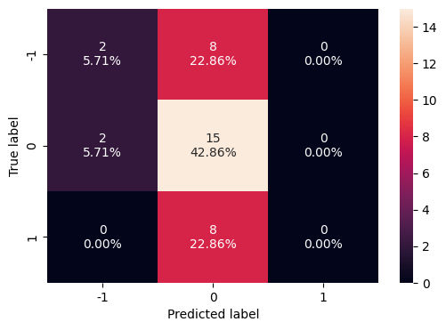

```python
confusion_matrix_sklearn(rf_word2vec, X_valid_word2vec, y_valid_word2vec)
```

```python
# Predicting on train data
y_pred_train_word2vec = rf_word2vec.predict(X_train_word2vec)

# Predicting on Validation data
y_pred_valid_word2vec = rf_word2vec.predict(X_valid_word2vec)
```

**Classification report**

```python
print(classification_report(y_train_word2vec, y_pred_train_word2vec,zero_division=0))
```

```
              precision    recall  f1-score   support

          -1       1.00      1.00      1.00        79
           0       1.00      1.00      1.00       136
           1       1.00      1.00      1.00        64

    accuracy                           1.00       279
   macro avg       1.00      1.00      1.00       279
weighted avg       1.00      1.00      1.00       279
```

```python
print(classification_report(y_valid_word2vec, y_pred_valid_word2vec,zero_division=0))
```

```
              precision    recall  f1-score   support

          -1       0.50      0.20      0.29        10
           0       0.48      0.88      0.62        17
           1       0.00      0.00      0.00         8

    accuracy                           0.49        35
   macro avg       0.33      0.36      0.30        35
weighted avg       0.38      0.49      0.39        35
```

**Observations**

- Model is heavily overfitting,generalises poorly and indicates dataset imbalance and Bias as it fails to predict even a single positive class correctly.

### RFModel-base-Glove

```python
# Building the Random Forest Base model using Glove Embedding
rf_glove = RandomForestClassifier(random_state = 42)

# Fitting on train data
rf_glove.fit(X_train_glove, y_train_glove)
```

```
RandomForestClassifier(random_state=42)
```

**Confusion Matrix**

```python
confusion_matrix_sklearn(rf_glove,X_train_glove,  y_train_glove)
```

[output not shown]

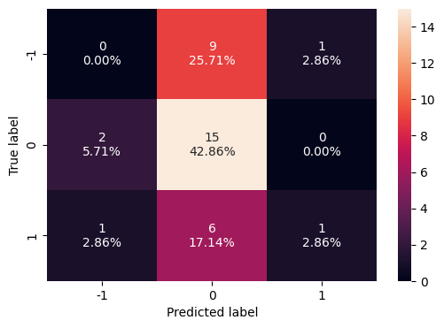

```python
confusion_matrix_sklearn(rf_glove, X_valid_glove, y_valid_glove)
```

```python
# Predicting on train data
y_pred_train_glove = rf_glove.predict(X_train_glove)

# Predicting on Validation data
y_pred_valid_glove = rf_glove.predict(X_valid_glove)
```

**Classification report**

```python
print(classification_report(y_train_glove , y_pred_train_glove,zero_division=0 ))
```

```
              precision    recall  f1-score   support

          -1       1.00      1.00      1.00        79
           0       1.00      1.00      1.00       136
           1       1.00      1.00      1.00        64

    accuracy                           1.00       279
   macro avg       1.00      1.00      1.00       279
weighted avg       1.00      1.00      1.00       279
```

```python
print(classification_report(y_valid_glove, y_pred_valid_glove,zero_division=0))
```

```
              precision    recall  f1-score   support

          -1       0.00      0.00      0.00        10
           0       0.50      0.88      0.64        17
           1       0.50      0.12      0.20         8

    accuracy                           0.46        35
   macro avg       0.33      0.34      0.28        35
weighted avg       0.36      0.46      0.36        35
```

**Observations** The model is overfitting, generalises poorly and fails to predict even a single Negative classcorrectly.

### RFModel-base-SentenceTransformers

```python
# Building the model
rf_sentence = RandomForestClassifier(random_state = 42)

# Fitting on train data
rf_sentence.fit(X_train_sentence, y_train_sentence)
```

```
RandomForestClassifier(random_state=42)
```

**Confusion Matrix**

```python
confusion_matrix_sklearn(rf_sentence,X_train_sentence,  y_train_sentence)
```

[output not shown]

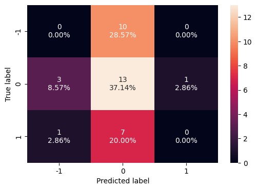

```python
confusion_matrix_sklearn(rf_sentence, X_valid_sentence, y_valid_sentence)
```

```python
# Predicting on train data
y_pred_train_sentence = rf_sentence.predict(X_train_sentence)

# Predicting on Validation data
y_pred_valid_sentence = rf_sentence.predict(X_valid_sentence)
```

```python
print(classification_report(y_train_sentence , y_pred_train_sentence,zero_division=0))
```

```
              precision    recall  f1-score   support

          -1       1.00      1.00      1.00        79
           0       1.00      1.00      1.00       136
           1       1.00      1.00      1.00        64

    accuracy                           1.00       279
   macro avg       1.00      1.00      1.00       279
weighted avg       1.00      1.00      1.00       279
```

```python
print(classification_report(y_valid_sentence, y_pred_valid_sentence,zero_division=0))
```

```
              precision    recall  f1-score   support

          -1       0.00      0.00      0.00        10
           0       0.43      0.76      0.55        17
           1       0.00      0.00      0.00         8

    accuracy                           0.37        35
   macro avg       0.14      0.25      0.18        35
weighted avg       0.21      0.37      0.27        35
```

**Observations**

The models is overfitting and struggles to generalise on validation data, failing to predict a single negative of positive sentiment.The outcome suggests small and havilty imbalanced dataset.

### RFModel-Word2Vec-HyperParameterTuned

```python
# import libraries To tune different models
from sklearn.model_selection import GridSearchCV
```

```python
from sklearn import metrics
```

```python
# Choose the type of classifier
rf_tuned = RandomForestClassifier(class_weight="balanced", random_state=42)

# defining the hyperparameter grid for tuning
parameters = {
    "max_depth": list(np.arange(4, 15, 2)),
    "max_features": ["sqrt", 0.5, 0.7],
    "min_samples_split": [5, 6, 7],
    "n_estimators": np.arange(30, 110, 10),
}

# defining the type of scoring used to compare parameter combinations
# we need to specify the mechanism of averaging as we have more than 2 target classes
scorer = metrics.make_scorer(metrics.recall_score, average='weighted')

# running the grid search
grid_obj = GridSearchCV(rf_tuned, parameters, scoring=scorer, cv=3, n_jobs=-1)
grid_obj = grid_obj.fit(X_train_word2vec, y_train_word2vec)
```

```python
# Creating a new model with the best combination of parameters
rf_word2vec_tuned = grid_obj.best_estimator_

# Fit the new model to the data
rf_word2vec_tuned.fit(X_train_word2vec, y_train_word2vec)
```

```
RandomForestClassifier(class_weight='balanced', max_depth=10, max_features=0.5,
                       min_samples_split=6, random_state=42)
```

**Confusion Matrix**

```python
confusion_matrix_sklearn(rf_word2vec_tuned, X_train_word2vec, y_train_word2vec)
```

[output not shown]

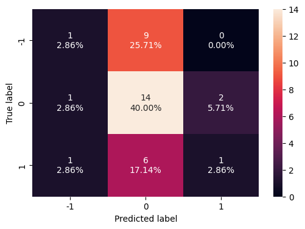

```python
confusion_matrix_sklearn(rf_word2vec_tuned, X_valid_word2vec, y_valid_word2vec)
```

```python
# Predicting on train data
y_pred_train_word2vec = rf_word2vec_tuned.predict(X_train_word2vec)

# Predicting on validation data
y_pred_valid_word2vec = rf_word2vec_tuned.predict(X_valid_word2vec)
```

```python
print(classification_report(y_train_word2vec, y_pred_train_word2vec,zero_division=0))
```

```
              precision    recall  f1-score   support

          -1       1.00      1.00      1.00        79
           0       1.00      1.00      1.00       136
           1       1.00      1.00      1.00        64

    accuracy                           1.00       279
   macro avg       1.00      1.00      1.00       279
weighted avg       1.00      1.00      1.00       279
```

```python
print(classification_report(y_valid_word2vec, y_pred_valid_word2vec,zero_division=0))
```

```
              precision    recall  f1-score   support

          -1       0.33      0.10      0.15        10
           0       0.48      0.82      0.61        17
           1       0.33      0.12      0.18         8

    accuracy                           0.46        35
   macro avg       0.38      0.35      0.31        35
weighted avg       0.41      0.46      0.38        35
```

**Observations**

- The model exhibits overfitting and poor generalization on validation data particularly on negative and positive sentiment

### RFModel-Glove-HyperParameterTuned

```python
# Choose the type of classifier
rf_tuned = RandomForestClassifier(class_weight="balanced", random_state=42)

# defining the hyperparameter grid for tuning
parameters = {
    "max_depth": list(np.arange(4, 15, 2)),
    "max_features": ["sqrt", 0.5, 0.7],
    "min_samples_split": [5, 6, 7],
    "n_estimators": np.arange(30, 110, 10),
}

# defining the type of scoring used to compare parameter combinations
# we need to specify the mechanism of averaging as we have more than 2 target classes
scorer = metrics.make_scorer(metrics.recall_score, average='weighted')

# running the grid search
grid_obj = GridSearchCV(rf_tuned, parameters, scoring=scorer, cv=3, n_jobs=-1)
grid_obj = grid_obj.fit(X_train_glove, y_train_glove)
```

```python
# Creating a new model with the best combination of parameters
rf_glove_tuned = grid_obj.best_estimator_

# Fit the new model to the data
rf_glove_tuned.fit(X_train_glove, y_train_glove)
```

```
RandomForestClassifier(class_weight='balanced', max_depth=4, max_features=0.7,
                       min_samples_split=6, n_estimators=90, random_state=42)
```

**Confusion Matrix**

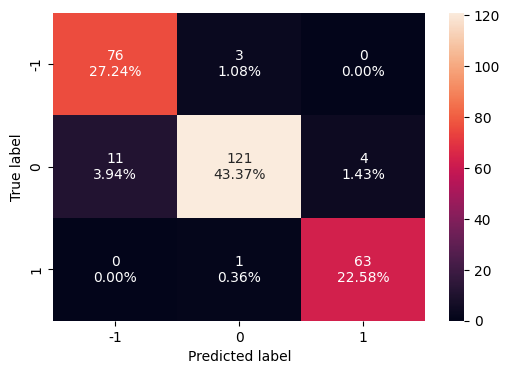

```python
#Printing the confusion matrix
confusion_matrix_sklearn(rf_glove_tuned, X_train_glove, y_train_glove)
```

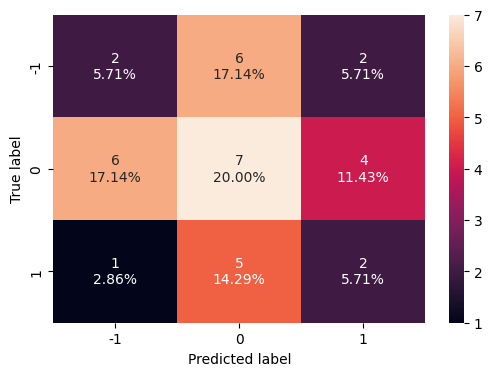

```python
#Printing the confusion matrix
confusion_matrix_sklearn(rf_glove_tuned, X_valid_glove, y_valid_glove)
```

```python
# Predicting on train data
y_pred_train_glove = rf_glove_tuned.predict(X_train_glove)

# Predicting on validation data
y_pred_valid_glove = rf_glove_tuned.predict(X_valid_glove)
```

```python
#Printing
print(classification_report(y_train_glove, y_pred_train_glove,zero_division=0))
```

```
              precision    recall  f1-score   support

          -1       0.87      0.96      0.92        79
           0       0.97      0.89      0.93       136
           1       0.94      0.98      0.96        64

    accuracy                           0.93       279
   macro avg       0.93      0.95      0.93       279
weighted avg       0.93      0.93      0.93       279
```

```python
print(classification_report(y_valid_glove, y_pred_valid_glove,zero_division=0))
```

```
              precision    recall  f1-score   support

          -1       0.22      0.20      0.21        10
           0       0.39      0.41      0.40        17
           1       0.25      0.25      0.25         8

    accuracy                           0.31        35
   macro avg       0.29      0.29      0.29        35
weighted avg       0.31      0.31      0.31        35
```

**Observations**

- The model performs strongly but overfits on training data and struggles to generalise on validation data particularly across positive and negative sentiments.

### RFModel-SentenceTrsformer-HyperParameterTuned

```python
# Choose the type of classifier
rf_tuned = RandomForestClassifier(class_weight="balanced", random_state=42)

# defining the hyperparameter grid for tuning
parameters = {
    "max_depth": list(np.arange(4, 15, 2)),
    "max_features": ["sqrt", 0.5, 0.7],
    "min_samples_split": [5, 6, 7],
    "n_estimators": np.arange(30, 110, 10),
}

# defining the type of scoring used to compare parameter combinations
# we need to specify the mechanism of averaging as we have more than 2 target classes
scorer = metrics.make_scorer(metrics.recall_score, average='weighted')

# running the grid search
grid_obj = GridSearchCV(rf_tuned, parameters, scoring=scorer, cv=3, n_jobs=-1)
grid_obj = grid_obj.fit(X_train_sentence, y_train_sentence)
```

```python
# Creating a new model with the best combination of parameters
rf_sentence_tuned = grid_obj.best_estimator_

# Fit the new model to the data
rf_sentence_tuned.fit(X_train_sentence, y_train_sentence)
```

```
RandomForestClassifier(class_weight='balanced', max_depth=6,
                       min_samples_split=7, n_estimators=60, random_state=42)
```

**Confusion Matrix**

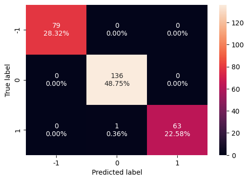

```python
#Printing the confusion matrix
confusion_matrix_sklearn(rf_sentence_tuned, X_train_sentence, y_train_sentence)
```

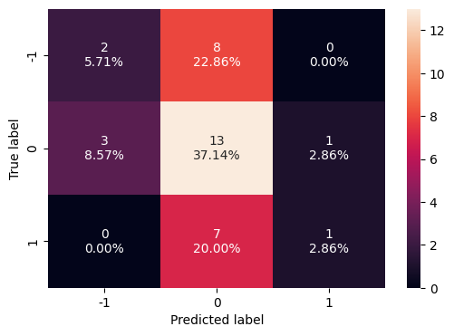

```python
#Printing the confusion matrix
confusion_matrix_sklearn(rf_sentence_tuned, X_valid_sentence, y_valid_sentence)
```

```python
# Predicting on train data
y_pred_train_sentence = rf_sentence_tuned.predict(X_train_sentence)

# Predicting on validation data
y_pred_valid_sentence = rf_sentence_tuned.predict(X_valid_sentence)
```

```python
#Printing
print(classification_report(y_train_glove, y_pred_train_glove,zero_division=0))
```

[output not shown]

```python
print(classification_report(y_valid_glove, y_pred_valid_glove,zero_division=0))
```

[output not shown]

**Observations**

- The model overfits the training and poorly generalises on the validation set.Validation performance is signifantly less and model is biased towards predicting newutral sentiment.

**Final Model Selection Evaluation Criteria**

- The base models of word2vec,glovw, and sentence transformer will not be considered because they failed to predict a single output of one of target classes
- We will also not selet HyperParameter tuned WordtoVec due to its achieving all perfecs scores on training data suggesting overfitting

# Model Testing

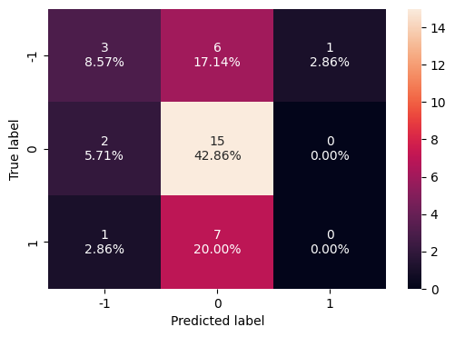

```python
confusion_matrix_sklearn(rf_sentence_tuned, X_test_sentence, y_test_sentence)
```

```python
# Predicting on test data
y_pred_test_sentence = rf_sentence_tuned.predict(X_test_sentence)
```

```python
print(classification_report(y_test_sentence, y_pred_test_sentence))
```

```
              precision    recall  f1-score   support

          -1       0.50      0.30      0.38        10
           0       0.54      0.88      0.67        17
           1       0.00      0.00      0.00         8

    accuracy                           0.51        35
   macro avg       0.35      0.39      0.35        35
weighted avg       0.40      0.51      0.43        35
```

## **Weekly News Summarization**

**Important Note**: It is recommended to run this section of the project independently from the previous sections in order to avoid runtime crashes due to RAM overload.

#### Installing and Importing the necessary libraries

```python
# installation for GPU llama-cpp-python
#!CMAKE_ARGS="-DLLAMA_CUBLAS=on" FORCE_CMAKE=1 pip install llama-cpp-python --force-reinstall --upgrade --no-cache-dir -q
```

```python
!CMAKE_ARGS="-DLLAMA_CUBLAS=on" FORCE_CMAKE=1
```

```python
!pip install llama-cpp-python --force-reinstall --upgrade --no-cache-dir
```

[output not shown]

```python
# Function to download the model from the Hugging Face model hub
from huggingface_hub import hf_hub_download

# Importing the Llama class from the llama_cpp module
from llama_cpp import Llama

# Importing the library for data manipulation
import pandas as pd

from tqdm import tqdm # For progress bar related functionalities
tqdm.pandas()
```

#### Loading the data

```python
from google.colab import drive
drive.mount('/content/drive')
```

```python
reviews = pd.read_csv("/content/drive/MyDrive/Python/stock_news.csv")
```

```python
datanlp=reviews.copy()
```

#### Loading the model

```python
## Model configuration
model_name_or_path = "TheBloke/Mistral-7B-Instruct-v0.2-GGUF"
model_basename = "mistral-7b-instruct-v0.2.Q6_K.gguf"
```

```python
model_path = hf_hub_download(
    repo_id=model_name_or_path,
    filename=model_basename
    )
```

```python
llm = Llama(
    model_path=model_path,
    n_ctx=1024,
)
```

[output not shown]

[output cut: 120 more lines]

[output not shown]

```python
import torch
print(torch.cuda.is_available())
```

```
True
```

#### Aggregating the data weekly

```python
datanlp["Date"] = pd.to_datetime(datanlp['Date'])  # Convert the 'Date' column to datetime format.
```

```python
# Group the data by week using the 'Date' column.
weekly_grouped = datanlp.groupby(pd.Grouper(key='Date', freq='W'))
```

```python
weekly_grouped = weekly_grouped.agg(
    {
        'News': lambda x: ' || '.join(x)  # Join the news values with ' || ' separator.
    }
).reset_index()

print(weekly_grouped.shape)
```

```
(18, 2)
```

```python
weekly_grouped
```

|  | Date | News |
| --- | --- | --- |
| 0 | 2019-01-06 | The tech sector experienced a significant dec... |
| 1 | 2019-01-13 | Sprint and Samsung plan to release 5G smartph... |
| 2 | 2019-01-20 | The U.S. stock market declined on Monday as c... |
| 3 | 2019-01-27 | The Swiss National Bank (SNB) governor, Andre... |
| 4 | 2019-02-03 | Caterpillar Inc reported lower-than-expected ... |
| 5 | 2019-02-10 | The Dow Jones Industrial Average, S&P 500, an... |
| 6 | 2019-02-17 | This week, the European Union's second highes... |
| 7 | 2019-02-24 | This news article discusses progress towards ... |
| 8 | 2019-03-03 | The Dow Jones Industrial Average and other ma... |
| 9 | 2019-03-10 | Spotify, the world's largest paid music strea... |
| 10 | 2019-03-17 | The United States opposes France's digital se... |
| 11 | 2019-03-24 | Facebook's stock price dropped more than 3% o... |
| 12 | 2019-03-31 | This news article reports that the S&P 500 In... |
| 13 | 2019-04-07 | Apple and other consumer brands, including LV... |
| 14 | 2019-04-14 | In March, mobile phone shipments to China dro... |
| 15 | 2019-04-21 | The chairman of Taiwan's Foxconn, Terry Gou, ... |
| 16 | 2019-04-28 | Taiwan's export orders continued to decline f... |
| 17 | 2019-05-05 | Spotify reported better-than-expected Q1 reve... |

#### Summarization

**Note**:

- The model is expected to summarize the news from the week by identifying the top three positive and negative events that are most likely to impact the price of the stock.
- As an output, the model is expected to return a JSON containing two keys, one for Positive Events and one for Negative Events.

For the project, we need to define the prompt to be fed to the LLM to help it understand the task to perform. The following should be the components of the prompt:

1. **Role**: Specifies the role the LLM will be taking up to perform the specified task, along with any specific details regarding the role
   - **Example**: `You are an expert data analyst specializing in news content analysis.`
2. **Task**: Specifies the task to be performed and outlines what needs to be accomplished, clearly defining the objective
   - **Example**: `Analyze the provided news headline and return the main topics contained within it.`
3. **Instructions**: Provides detailed guidelines on how to perform the task, which includes steps, rules, and criteria to ensure the task is executed correctly
   - **Example**:

```
Instructions:
1. Read the news headline carefully.
2. Identify the main subjects or entities mentioned in the headline.
3. Determine the key events or actions described in the headline.
4. Extract relevant keywords that represent the topics.
5. List the topics in a concise manner.
```

1. **Output Format**: Specifies the format in which the final response should be structured, ensuring consistency and clarity in the generated output
   - **Example**: `Return the output in JSON format with keys as the topic number and values as the actual topic.`

**Full Prompt Example**:

```
You are an expert data analyst specializing in news content analysis.

Task: Analyze the provided news headline and return the main topics contained within it.

Instructions:
1. Read the news headline carefully.
2. Identify the main subjects or entities mentioned in the headline.
3. Determine the key events or actions described in the headline.
4. Extract relevant keywords that represent the topics.
5. List the topics in a concise manner.

Return the output in JSON format with keys as the topic number and values as the actual topic.
```

**Sample Output**:

`{"1": "Politics", "2": "Economy", "3": "Health" }`

##### Utility Functions

```python
# defining a function to parse the JSON output from the model
def extract_json_data(json_str):
    import json
    try:
        # Find the indices of the opening and closing curly braces
        json_start = json_str.find('{')
        json_end = json_str.rfind('}')

        if json_start != -1 and json_end != -1:
            extracted_category = json_str[json_start:json_end + 1]  # Extract the JSON object
            data_dict = json.loads(extracted_category)
            return data_dict
        else:
            print(f"Warning: JSON object not found in response: {json_str}")
            return {}
    except json.JSONDecodeError as e:
        print(f"Error parsing JSON: {e}")
        return {}
```

##### Defining the response function

```python
#Defining the response function
def response_mistral_1(prompt, news):
    model_output = llm(
      f"""
      [INST]
      {prompt}
      News Articles: {news}
      [/INST]
      """,
      max_tokens=128, #Complete the code to set the maximum number of tokens the model should generate for this task.
      temperature=0, #Complete the code to set the value for temperature.
      top_p=0.95, #Complete the code to set the value for top_p
      top_k=50, #Complete the code to set the value for top_k
      echo=False,
    )

    final_output = model_output["choices"][0]["text"]

    return final_output
```

**Note**: Use this section to test out the prompt with one instance before using it for the entire weekly data.

```python
# Define the prompt as a string (with system instructions and JSON format)
prompt = """
You are a highly intelligent financial assistant specialized in stock market analysis and natural language processing.

As a member of the Data Science and AI team in a fintech startup, your role is to analyze news articles related to a specific stock and summarize the overall market sentiment at a weekly level. Your goal is to help financial analysts make more informed investment decisions.

Your task is:
- Analyze all the news articles from the past week.
- Identify and summarize the top **three most positive** and **three most negative** events that could impact the stock price.
- Focus on summarizing key events, their likely impact on stock performance, and overall market sentiment.

Output the summary in the following **JSON format**:

{
  "week_start": "YYYY-MM-DD",
  "week_end": "YYYY-MM-DD",
  "summary": {
    "top_positive_events": [
      {"event": "Brief description", "impact": "Likely positive impact on stock because..."},
      ...
    ],
    "top_negative_events": [
      {"event": "Brief description", "impact": "Likely negative impact on stock because..."},
      ...
    ],
    "overall_sentiment": "Positive | Negative | Neutral"
  }
}
"""
```

```python
data_instruct_3 = weekly_grouped.copy()
```

```python
# Run the function on the first row
instruct3_response3 = response_mistral_1(prompt, data_instruct_3.iloc[0])
```

```
llama_perf_context_print:        load time =  175534.10 ms
llama_perf_context_print: prompt eval time =  175533.18 ms /   369 tokens (  475.70 ms per token,     2.10 tokens per second)
llama_perf_context_print:        eval time =  106525.87 ms /   127 runs   (  838.79 ms per token,     1.19 tokens per second)
llama_perf_context_print:       total time =  282128.74 ms /   496 tokens
```

```python
print(instruct3_response3)
```

[output not shown]

```python
model_instruct3_response3 = data_instruct_3 .apply(lambda row: response_mistral_1(prompt, row), axis=1)
```

[output not shown]

[output cut: 35 more lines]

[output not shown]

```python
model_instruct3_response3
```

|  | 0 |
| --- | --- |
| 0 | {\n "week_start": "2019-01-06",\n ... |
| 1 | {\n "week_start": "2019-01-13",\n ... |
| 2 | {\n "week_start": "2019-01-20",\n ... |
| 3 | {\n "week_start": "2019-01-27",\n ... |
| 4 | {\n "week_start": "2019-02-01",\n ... |
| 5 | {\n "week_start": "2019-02-07",\n ... |
| 6 | {\n "week_start": "2019-02-11",\n ... |
| 7 | {\n "week_start": "2019-02-21",\n ... |
| 8 | {\n "week_start": "2019-03-01",\n ... |
| 9 | {\n "week_start": "2019-03-01",\n ... |
| 10 | {\n "week_start": "2019-03-11",\n ... |
| 11 | {\n "week_start": "2019-03-21",\n ... |
| 12 | {\n "week_start": "2019-03-31",\n ... |
| 13 | {\n "week_start": "2019-04-01",\n ... |
| 14 | {\n "week_start": "2019-04-14",\n ... |
| 15 | {\n "week_start": "2019-04-14",\n ... |
| 16 | {\n "week_start": "2019-04-21",\n ... |
| 17 | {\n "week_start": "2019-05-05",\n ... |

**dtype:** object

## **Conclusions and Recommendations**

**Conclusions**

**Recommendations**

- Implemetation of Customer Altert notification in large Negative Sentiments event deection scenario will boost cusomter confidence(both for exit strategy or customers who buy more when prices are down.
- Weekly Summary can be incorporated with Analysts Portals/dashboards to increase their efficiency.
- Weekly Summary data can be aggregated over time and used to better the stock price prediction

Power Ahead